# How happy are you? A comparison between Italy and Finland.

Vanessa, Anita and Anna

25 gennaio 2021

In this analysis we have used the European Social Survey data (Round 9 – 2018) to investigate the level of happiness a European citizen says to be. To begin with our small research, the variable chosen was “happy” which is formulated for the survey into the following question: “Taking all things together, how happy would you say you are?” The categories in which the answer could fall are comprised within 0 (extremely unhappy) to 10 (extremely happy). The analysis wanted to be a comparison between two countries. Hence, to direct our analysis on a significant and not random comparison, we appealed to the 2018 Eurostat report (https://ec.europa.eu/eurostat/web/products-eurostat-news/-/DDN-20191107-1) on the happiest European country of the year. Although the survey question was different (“rank your frequency of being happy in the past four weeks”), it was still an important starting point for the choice of our countries: we opted for Italy, since it is our home country, and for Finland since in the Eurostat report it is the highest ranked country.

```r
library(tidyverse)
library(rio)

happy_data <- import("ESS1-9e01.csv")
```

At this point, data was cleared: firstly, all countries except from Italy and Finland were dropped and secondly, all subjects with missing observations (refusal *[code: 77]*, don’t know *[code: 88]*, no answer *[code: 99]*) on the variable of interest were deleted form the analysis.

```r
happy_cntry <- filter(
  happy_data,
  cntry %in% c("IT", "FI"),
  !(happy==77 | happy==88 | happy==99)
)

happy_it <- happy_cntry %>% filter (cntry == "IT")

happy_fi <- happy_cntry %>% filter (cntry == "FI")
```

##### Plots

The happiness level plot in Italy presents a gradually increasing frequency up to happiness level 8 (highest peak registered with more than 600 respondents) and then decreases radically for level 9 and 10.

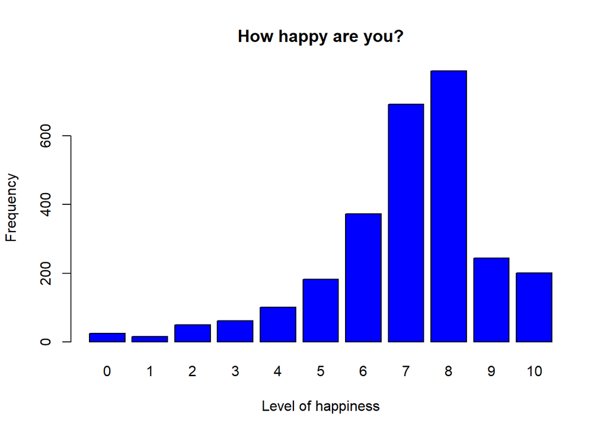

```r
barplot((table(happy_it$happy)),
        col="blue",
        xlab = "Level of happiness",
        ylab = "Frequency",
        main = "How happy are you?")
```

For what concerns the happiness level plot in Finland, instead, it pictures its highest frequencies at happiness level 8 and 9 to then decrease significantly at level 10.

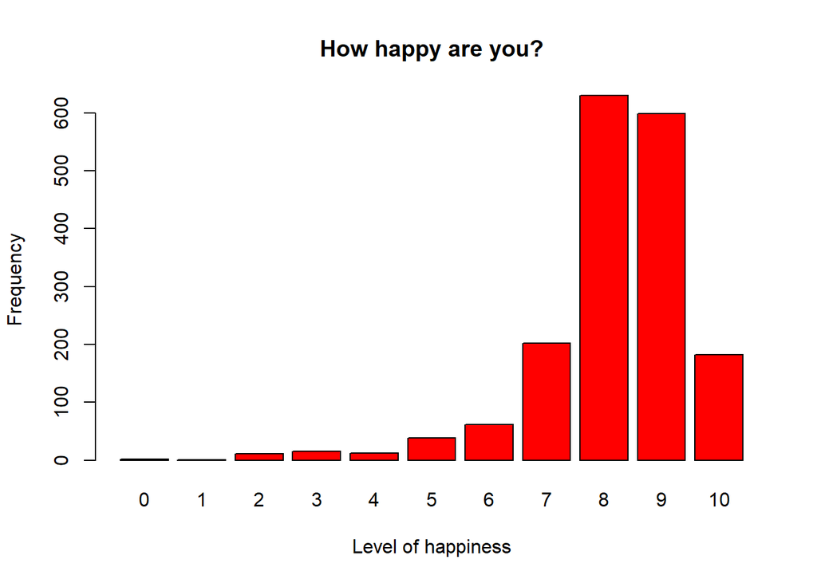

```r
barplot((table(happy_fi$happy)),
        col="red",
        xlab = "Level of happiness",
        ylab = "Frequency",
        main = "How happy are you?")
```

The Italian plot is less skewed to the left than the Finnish one, this means that the people from Finland are generally more happy than the ones from Italy. We should bear in mind that Italy presents almost 1000 observations more than Finland and this makes it hard to make a comparison.

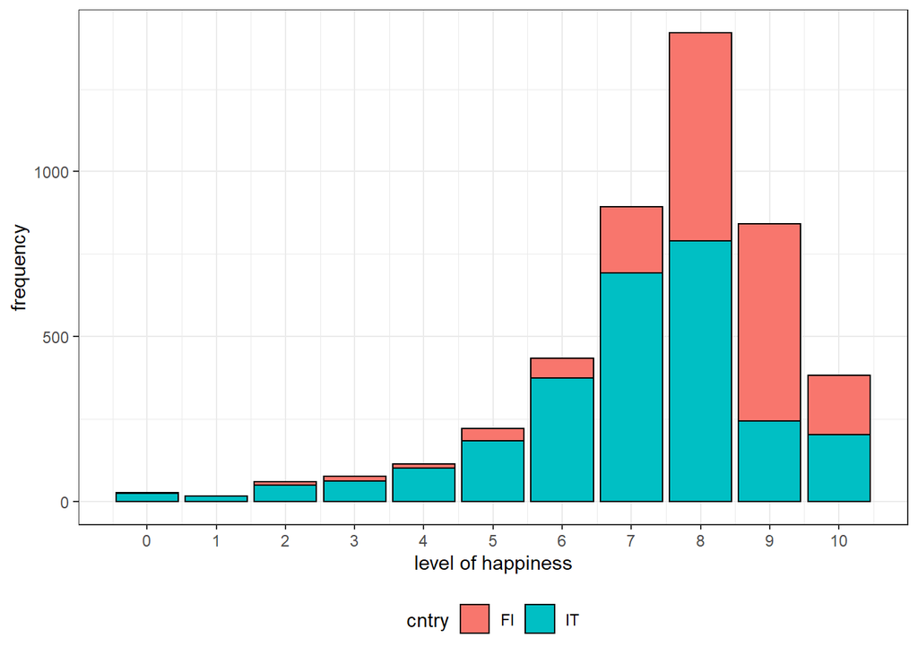

```r
happy_cntry %>%
  ggplot(aes(x = happy, fill = cntry)) +
  geom_bar(alpha = 1, col = "black", binwidth = 10) +
  scale_x_continuous(breaks = seq(0, 10, by = 1))+
  scale_color_manual(values = c("red", "blue")) +
  xlab("level of happiness") +
  ylab("frequency") +
  theme_bw() +
  theme(legend.position = "bottom")
```

To be sure that the difference between the happiness level in Italy and Finland is statistically significant, we decided to compute a t-test to compare the two means.

##### T-Test

We decided to test the differences between these two specific countries because we supposed that the Finns could be happier than the Italians because of their better economical and socio-political situation.

```r
t.test(happy_it$happy, happy_fi$happy, var.equal = TRUE)
```

```
##
##  Two Sample t-test
##
## data:  happy_it$happy and happy_fi$happy
## t = -22.215, df = 4483, p-value < 2.2e-16
## alternative hypothesis: true difference in means is not equal to 0
## 95 percent confidence interval:
##  -1.245415 -1.043424
## sample estimates:
## mean of x mean of y
##  7.033663  8.178082
```

As can be seen, we can reject the hypothesis that the level of happiness is the same between the two countries (H0). It is possible to observe that the confidence interval does not contain 0, the t value is very large (t=-22.215), and the p-value is very small (P=0.000). Given these results, it is possible to state that there is a statistically significant difference between the level of happiness between Italy and Finland.

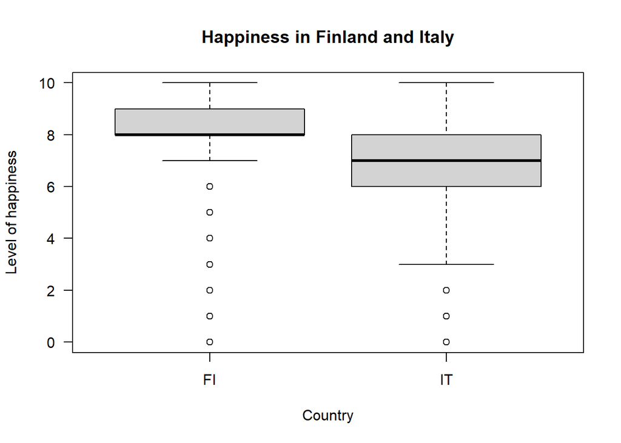

```r
boxplot(happy ~ cntry, data = happy_cntry,
        horizzontal = F,
        las = 1,
        xlab = "Country",
        ylab = "Level of happiness",
        main = "Happiness in Finland and Italy")
```

Again, in this box plot, it is possible to observe that the mean difference of the level of happiness in the two countries is different, in particular, Italians are on average less happy than Finns.